# What is the Probability of Winning the World Series?

Sarah Torrence

September 24, 2020

# Introduction

What is the probability of winning the World Series? Well the answer is not that easy because it involves up to 7 individual baseball games. Each of those individual games involves two teams and each of their probabilities of winning. Here I will explore the important variables that determine the probability of winning the World Series and how changing them might impact a team’s chances of winning.

## Background

For those who are unaware of baseball and it’s rules, fear not this post is all about probability and you do not need to understand baseball. The World Series is a best-of-7 match-up between the champions of the American and National Leagues of Major League Baseball. This means the two teams will play until one of them wins 4 games. If a team wins the first 4 games, the series is over and that team wins. It will only get to 7 games if the teams are tied 3 for 3 after the first 6 games and must play a seventh to break the tie. How does the best-of-7 impact the probability of each team winning the World Series?

Here I will investigate a few questions to explore in understanding the parameters, or factors, involved in figuring out the probability a team wins the World Series. For this exploration I have set our two teams to be the Braves and the Yankees. Feel free to substitute in your two favorite teams and the exact same rules apply. I am assuming the probability the Braves win the World Series to be *P*<sub>*B*</sub> and the probability the Yankees win to be *P*<sub>*Y*</sub> = 1 - *P*<sub>*B*</sub>. I will aim to answer the following questions:

1. What is the probability that the Braves win the World Series given that *P*<sub>*B*</sub> = 0.55?
2. What is the probability that the Braves win the World Series given that *P*<sub>*B*</sub> = *x*?
3. Suppose one could change the World Series to be best-of-9 or some other best-of-X series. What is the shortest series length so that *P*(Braves win World Series|*P*<sub>*B*</sub> = .55) ≥ 0.8?
4. What is the shortest series length so that *P*(Braves win World Series|*P*<sub>*B*</sub> = *x*) ≥ 0.8?
5. What is *P*(*P*<sub>*B*</sub> = 0.55|Braves win World Series in 7 games) under the assumption that either *P*<sub>*B*</sub> = 0.55 or *P*<sub>*B*</sub> = 0.45?

Before answering these questions, we will need to understand a bit about Bernoulli random variables, the binomial distribution and the negative binomial distribution.

**Bernoulli Random Variable:** A process or experiment that generates a binary outcome (0 or 1) assuming outcomes are independent and the probability of each outcome is constant. A classic example is flipping a coin with the outcomes heads or tails. In this case the Bernoulli random variable is a win or loss of a single baseball game.

$P_B^k(1-P_B)^{1-k}$ for $k \in \{0,1\}$ where $k$ is the possible outcomes (1 for a win and 0 for a loss).

This is a specific case of the binomial distribution where $n = 1$ so the outcome of just one game in the series.

**Binomial distribution:** The number of successes in a Bernoulli sequence assuming outcomes are independent and the probability of each outcome is constant. A binomial distribution is typically the number of $x$ events happening in $N$ trials. In our case, the number of head-to-head wins out of the total number of games played in the series.

$\binom{N}{k} P_B^k(1-P_B)^{N-k}$

**Negative Binomial Distribution:** The number of failures before a success in a Bernoulli sequence assuming outcomes are independent and the probability of each outcome is constant. In other words, the number of lost baseball games until a win. Here the number of trials can be infinite and $r$ is the number success (the stopping rule).

$\sum_{k=0}^{\infty}\binom{-r}{k}(-P_B)^k$

The “success” or “win” in our case does not need to be just 1 win. In the World Series a team does not win until they have won 4 head-to-head games. You can think of the success as more of a stopping rule. What is the probability a team wins at least 4 of the 7 games in a World Series? Here the stopping rule is 4 games. If they win the first 4 games, great we stop. If it takes up to 7 that is fine they still win, but the sequence stops when 4 games are won by one team.

# Exploration

I will answer our questions one by one and conclude with our overall results in understanding the probability of winning the World Series.

#### 1. What is the probability that the Braves win the World Series given that *P*<sub>*B*</sub> = 0.55?

```r
p_braves <- pnbinom(3,4,0.55)
```

To understand the probability a team will win the World Series, we must know what the probability is that they will win a single game. Here we are assuming the Braves have a 55% chance of winning each individual game against the Yankees. To understand how this relates to the distributions we have defined, this question can be restated as the following: What is the probability that the Braves will win at least 4 of the 7 games to win the World Series?

This means we can use the negative binomial distribution to find the probability that the Braves and the Yankees have a sequence of games where the Braves win 4 before we get to 7 total games. Plugging these values into our formula for the negative binomial distribution we find that the probability the Braves win the World Series given *P*<sub>*B*</sub> = 0.55, is 0.6082878.

#### 2. What is the probability that the Braves win the World Series given that *P*<sub>*B*</sub> = *x*?

Taking the first question a step further, what if we don’t know the probability that the Braves will win a head-to-head game against the Yankees? How will changing their chances of winning each games effect their chances of winning the World Series?

This can be done by taking the negative binomial distribution from question 1 and plugging in a sequence of different probabilities between 0 and 1. Here I graph the results.

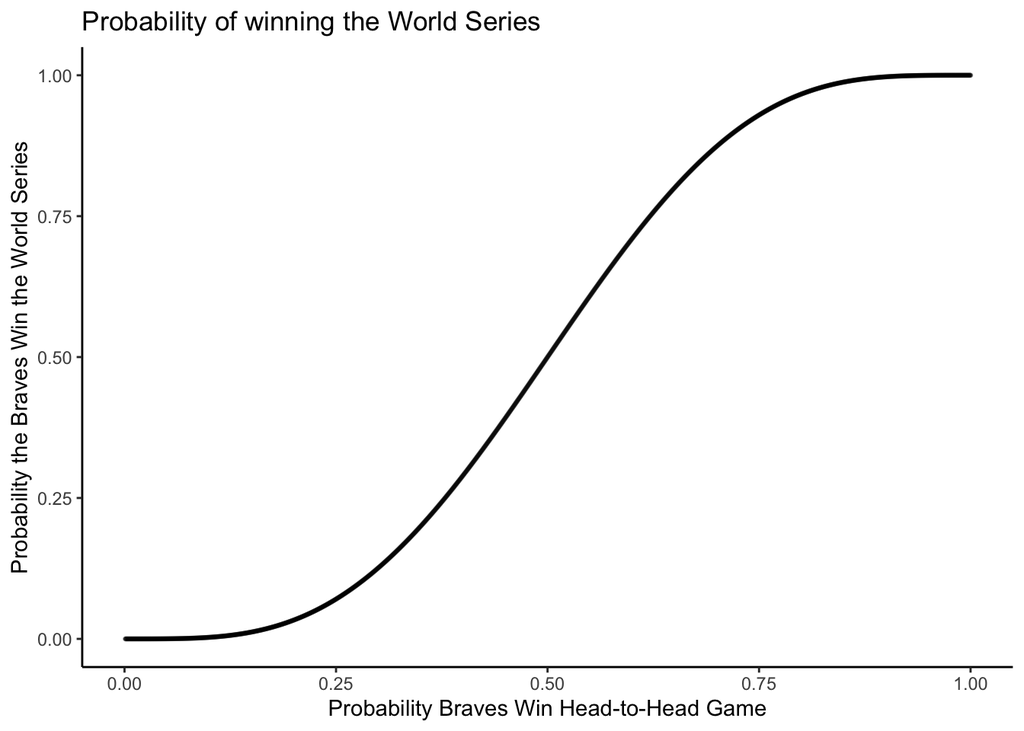

```r
p_world_series <- function(p) {
  #Computes the probability that a team will win the World Series given the
  #probability that they will win a head-to-head matchup
  p_win <- pnbinom(3,4,p)
  return(p_win)
}

#vector of different probabilities of the Braves winning a head-to-head matchup
p_braves <- seq(0,1,.001)

#Calculate the probability of winning the world series across a range of different possible game probabilities
p_braves_win_world_series <- c()
for(i in 1:length(p_braves)) {
  p_braves_win_world_series[i] <- p_world_series(p_braves[i])
}

#Create a dataframe with the two probability vectors
world_series <- data.frame(p_braves, p_braves_win_world_series)

#plot the dataframe
world_series %>% ggplot(aes(x = p_braves, y = p_braves_win_world_series)) +
  geom_point(alpha =.5, size = .5) +
  labs(
      title="Probability of winning the World Series",
      y="Probability the Braves Win the World Series",
      x="Probability Braves Win Head-to-Head Game"
      ) +
      theme_classic()
```

As you might have expected, the higher the probability the Braves have of winning each individual game increases their changes of winning the entire series. It is interesting to note that it is not a direct relationship. The curve is S-shaped meaning between approximately *P*<sub>*B*</sub> = 0.25 and *P*<sub>*B*</sub> = 0.75 as *P*<sub>*B*</sub> increases, the Braves chances of winning the World Series rapidly increases while with low probabilities and high probabilities of winning each individual games, their chances of winning the World Series are not effected as much by changes in *P*<sub>*B*</sub>.

#### 3. Suppose one could change the World Series to be best-of-9 or some other best-of-X series. What is the shortest series length so that *P*(Braves win World Series|*P*<sub>*B*</sub> = .55) ≥ 0.8?

Looking at our results from question 1, we know it must be higher than a series of 7. To find the answer, I took the negative binomial distribution and plugged in a sequence of increasing games series until I found a series where the probability of winning was greater than or equal to 0.8.

| Total Games in the Series | Number of Braves Wins | Number of Yankees Wins |
| --- | --- | --- |
| 7 | 4 | 3 |
| 9 | 5 | 4 |
| 11 | 6 | 5 |
| 13 | 7 | 6 |
| … | … | … |

Here I plotted the results:

```r
#initializing the number of wins, losses and probability of winning the series
num_win <- 1
num_loss <- num_win - 1
p_win <- 0

#finding the number of games in which the probability of winning the series is at least 0.8
while (p_win < 0.8){
  num_win <- num_win + 1
  num_loss <- num_loss + 1
  p_win <- pnbinom(num_loss,num_win,0.55)
}

#adding up the wins and losses to get the total number of games
total_games <- num_win + num_loss
```

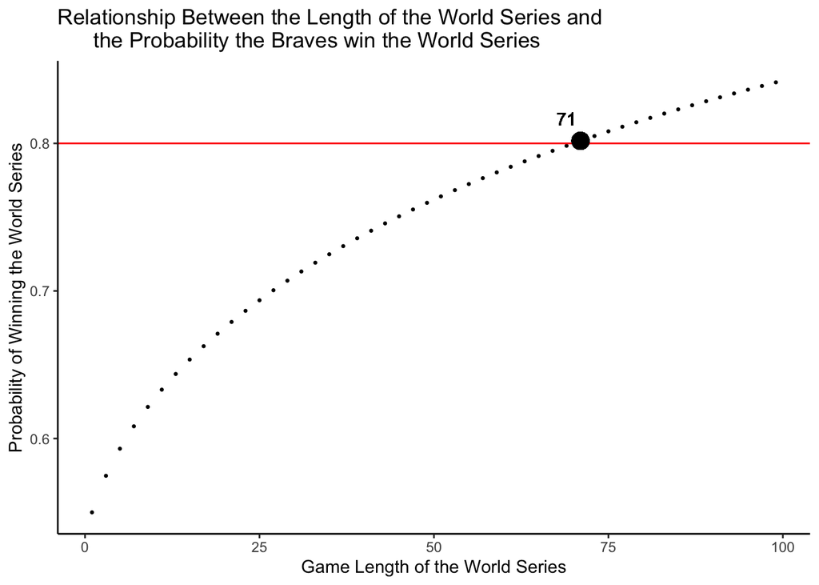

```r
#Lets try to plot this
#iterate over a sequence of series of different length up to 100 and calculate the probability of winning at each series number
p <- c()
games <- c()
x <- seq(1,100,2)
for (i in x){
  num_wins <- ceiling(i/2)
  num_losses <- num_wins - 1
  p[i] <- pnbinom(num_losses,num_wins,0.55)
  games[i] <- num_wins + num_losses
}

#Put series lengths and associated probabilities into a dataframe
series <- data.frame(p,games)
series <- series %>% drop_na()

#plot the series dataframe
series %>% ggplot(aes(x = games, y = p)) +
  geom_point(alpha =1, size = .5) +
  labs(
      title="Relationship Between the Length of the World Series and
      the Probability the Braves win the World Series",
      x = "Game Length of the World Series",
      y = "Probability of Winning the World Series"
      ) +
  geom_hline(yintercept = 0.8, color = "red") +
  geom_text(aes(x = total_games - 2, y = p_win +  0.015, label = "71")) +
  geom_point(aes(x = total_games, y = p_win, size = .02)) +
  theme_classic() +
  theme(legend.position = "none")
```

Using this method, I found the total number of games in a series in which the probability of the Braves winning was at least 0.8 given *P*<sub>*B*</sub> = .55, was 71 with *P*(Braves win World Series) = 0.8017017. This means the Braves would have to win 36 games to win that series. That is a lot of games! As you can see from the graph, as the length of the series increases, the Braves’ chance of winning increases. The more we increase the games in a series, the acceleration of the probability increases of winning slows down.

#### 4. What is the shortest series length so that *P*(Braves win World Series|*P*<sub>*B*</sub> = *x*) ≥ 0.8?

In this question we are taking what we learned from question 3 and looking a little deeper. In question 3, we assumed *P*<sub>*B*</sub> = .55, but here *P*<sub>*B*</sub> is some arbitrary number. We are still using the negative binomial distribution here, but we are missing two of the parameters and trying to find all different possible combinations of *P*<sub>*B*</sub> and series lengths where the Braves’ probability of winning the entire series is at least 0.8. I found all results from a sequence of *P*<sub>*B*</sub>s from 0.51 to 1 and a sequence of series lengths from 1 to 301 and filtered for only those who resulted in a probability of the Braves winning the series of at least 0.8. Here I have plotted my results:

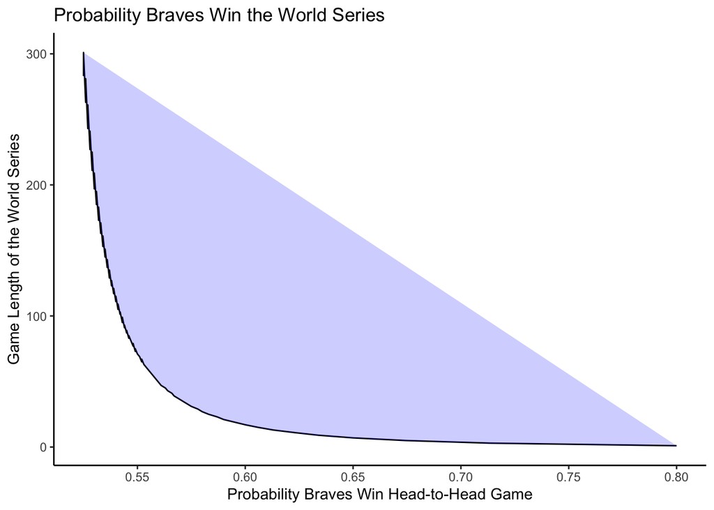

```r
#create a dataframe of probabilities and series lengths
series <- expand.grid(
  p = seq(0.51,1,.001),
  games = seq(1,301,2),
  p_hat = NA_real_
)

#calculate the probability for each p and series length combination
for(i in 1:nrow(series)) {
  num_wins <- ceiling(series[i,"games"]/2)
  num_loss <- num_wins - 1
  series[i,"p_hat"] <- pnbinom(num_loss,num_wins,series[i,"p"])
}

#filter for the shortest series lengths where p_hat is greater than 0.8
shortest_series <- series %>% filter(p_hat >= .8) %>%
                      arrange(games, p) %>%
                      group_by(games) %>%
                      slice(1)

#plot the results
shortest_series %>% ggplot(aes(x = p, y = games)) +
  geom_line() +
  labs(
        title="Probability Braves Win the World Series",
        y = "Game Length of the World Series",
        x = "Probability Braves Win Head-to-Head Game"
        ) +
  scale_x_continuous(
            breaks=seq(0, 0.8, 0.05),
            ) +
  geom_polygon(aes(p, games), fill="blue", alpha=0.2) +
  theme_classic()
```

If the Braves want at least an 80% chance of winning the World Series they must fall somewhere on or above this curve. The smaller their probability of winning each individual game, the longer the series needs to be to guarantee them an 80% to win the series. This graph shows a negative exponential relationship between game length of a series and the probability of the Braves winning a head-to-head game. If the Braves do not want to play a large number of games to keep an 80% chance of winning they must improve their chances of winning each individual game.

#### 5. What is *P*(*P*<sub>*B*</sub> = 0.55|Braves win World Series in 7 games) under the assumption that either *P*<sub>*B*</sub> = 0.55 or *P*<sub>*B*</sub> = 0.45?

This question is a bit different than the others in that here we are assuming the Braves won the World Series in exactly 7 games. This means they won 3 and lost 3 in any order and then won the last game to win 4 out of 7 games total. We must also assume that the probability that *P*<sub>*B*</sub> is 0.55 or 0.45 is exactly equal. To solve this problem I created a table of probabilities with all the possible outcomes.

```r
#Column of probabilities in which the Braves win in exactly 7 games
win <- c(dnbinom(3,4,0.55),
         dnbinom(3,4,0.55)*0.5,
         dnbinom(3,4,0.55)*0.5/(dnbinom(3,4,0.55)*0.5 +  dnbinom(3,4,0.45)*0.5),
         dnbinom(3,4,0.45),
         dnbinom(3,4,0.45)*0.5,
         dnbinom(3,4,0.45)*0.5/(dnbinom(3,4,0.55)*0.5 +  dnbinom(3,4,0.45)*0.5)
        )

#column of probabilities in which the Braves do not win in exactly 7 games
not_win <- c(
              0.5-dnbinom(3,4,0.55),
             0.5-(dnbinom(3,4,0.55)*0.5),
             (0.5-dnbinom(3,4,0.55)*0.5)/(0.5-dnbinom(3,4,0.55)*0.5 + 0.5-dnbinom(3,4,0.45)*0.5),
             0.5-dnbinom(3,4,0.45),
             0.5-dnbinom(3,4,0.45)*0.5,
             (0.5-dnbinom(3,4,0.45)*0.5)/((0.5-dnbinom(3,4,0.55)*0.5) + (0.5-dnbinom(3,4,0.45)*0.5))
              )

#putting columns together in a dataframe
table_values <- data.frame(win,not_win)

#calculating the column totals
col_totals <- c(dnbinom(3,4,0.55)*0.5 +  dnbinom(3,4,0.45)*0.5,
                (0.5-dnbinom(3,4,0.55)*0.5) +
                (0.5-dnbinom(3,4,0.45)*0.5)
                )
```

[figure not shown]

We could also solve this problem using Bayes Rule:

$\Pr(A|B)=\frac{\Pr(B|A)\Pr(A)}{\Pr(B)}$

in this case:

$P(P_B = 0.55|Braves win World Series in 7 Games)=\frac{P(Braves win World Series in 7 Games|P_B = 0.55)P(P_B = 0.55)}{P(Braves win World Series in 7 Games)} = \frac{0.1668*0.5}{0.1516} = 0.55$

# Conclusion

We now understand how to calculate the probability of winning the World Series using negative binomial distributions. We also now understand how the length of the series and probability of a team winning an individual game impacts the probability that team wins the entire series. With that being said, we are limited to our assumptions and there could be a lot of other variables at play that could also effect the probability of winning the World Series. For this exploration we assumed the probability of winning each individual game stayed constant, but that might not be the case. The games within the World Series are played in the stadiums in which the teams reside. This means at each game there is a home team and an away team. This could affect each individual game probability depending on where the game is played. Further, what if a team’s star player gets injured after the first game? There are just a couple of numerous factors that could break our assumption and change the outcome of our results. Of course we cannot include all factors in our analysis, but it is important to remember the limitations of our outcomes and what other factors we could include in the future to see their impact on a team’s probability to win the World Series.